# Project 5 - Travel Package Purchase Prediction

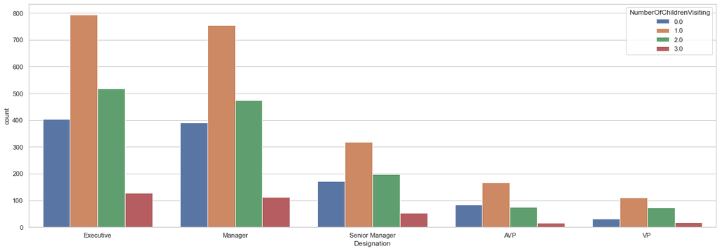

```python
sns.set_theme(style="whitegrid")
sns.countplot(
    data=df, x="Designation", hue="NumberOfChildrenVisiting", order=ordered_designation
)
```

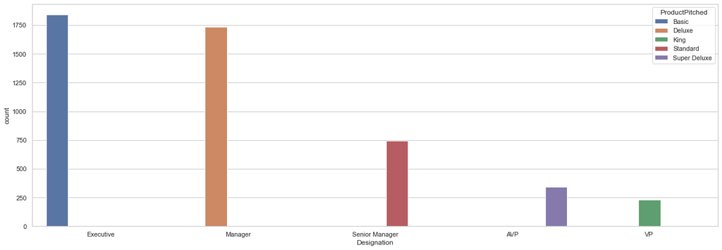

```python
sns.set_theme(style="whitegrid")
sns.countplot(data=df, x="Designation", hue="ProductPitched", order=ordered_designation)
```

```python
df.groupby(["Designation", "ProductPitched"]).size()
```

```
Designation     ProductPitched
AVP             Basic                0
                Deluxe               0
                King                 0
                Standard             0
                Super Deluxe       342
Executive       Basic             1842
                Deluxe               0
                King                 0
                Standard             0
                Super Deluxe         0
Manager         Basic                0
                Deluxe            1732
                King                 0
                Standard             0
                Super Deluxe         0
Senior Manager  Basic                0
                Deluxe               0
                King                 0
                Standard           742
                Super Deluxe         0
VP              Basic                0
                Deluxe               0
                King               230
                Standard             0
                Super Deluxe         0
dtype: int64
```

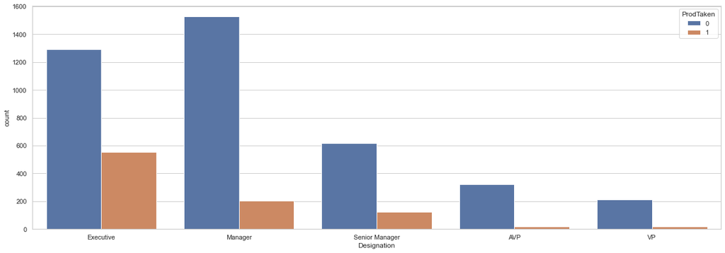

```python
sns.set_theme(style="whitegrid")
sns.countplot(data=df, x="Designation", hue="ProdTaken", order=ordered_designation)
```

```python
df.groupby(["Designation", "ProdTaken"]).size()
```

```
Designation     ProdTaken
AVP             0             322
                1              20
Executive       0            1290
                1             552
Manager         0            1528
                1             204
Senior Manager  0             618
                1             124
VP              0             210
                1              20
dtype: int64
```

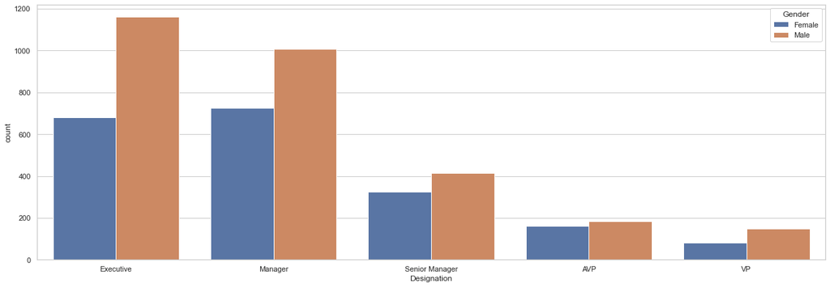

```python
sns.set_theme(style="whitegrid")
sns.countplot(data=df, x="Designation", hue="Gender", order=ordered_designation)
```

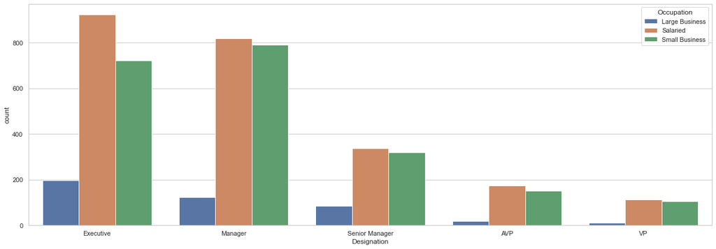

```python
sns.set_theme(style="whitegrid")
sns.countplot(data=df, x="Designation", hue="Occupation", order=ordered_designation)
```

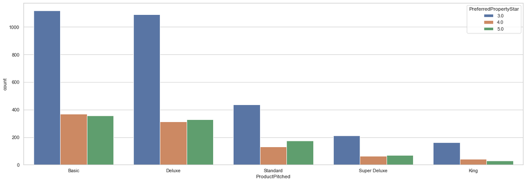

```python
ordered_pitch = ["Basic", "Deluxe", "Standard", "Super Deluxe", "King"]
sns.set_theme(style="whitegrid")
sns.countplot(
    data=df, x="ProductPitched", hue="PreferredPropertyStar", order=ordered_pitch
)
```

- This visual surprised me a bit. I would have thought the Super Deluxe and King properties would have had a higher star rating. Since all the trips are across the board 3 stars I feel like the people across the board are not that happy with the packages.

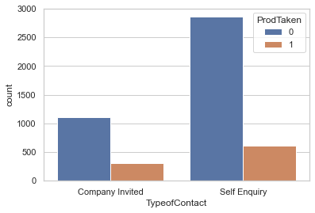

```python
sns.set_theme(style="whitegrid")
sns.countplot(data=df, x="TypeofContact", hue="ProdTaken")
```

```python
df.groupby(["TypeofContact", "ProdTaken"]).size() / len(df)
```

```
TypeofContact    ProdTaken
Company Invited  0            0.226882
                 1            0.063421
Self Enquiry     0            0.584902
                 1            0.124795
dtype: float64
```

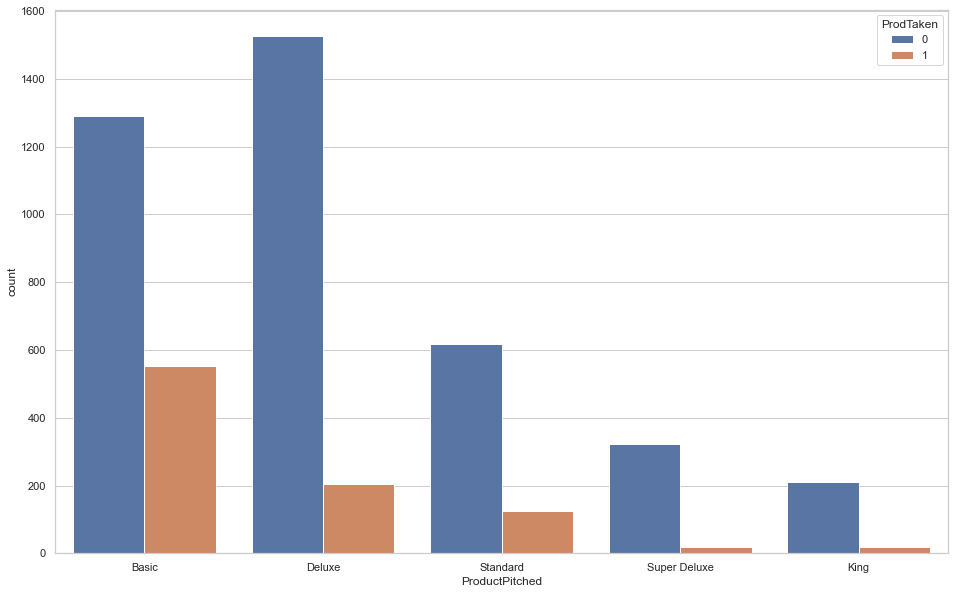

```python
sns.set_theme(style="whitegrid")
sns.countplot(data=df, x="ProductPitched", hue="ProdTaken", order=ordered_pitch)
```

```python
df.groupby(["ProductPitched", "ProdTaken"]).size() / len(df)
```

```
ProductPitched  ProdTaken
Basic           0            0.263912
                1            0.112930
Deluxe          0            0.312602
                1            0.041735
King            0            0.042962
                1            0.004092
Standard        0            0.126432
                1            0.025368
Super Deluxe    0            0.065876
                1            0.004092
dtype: float64
```

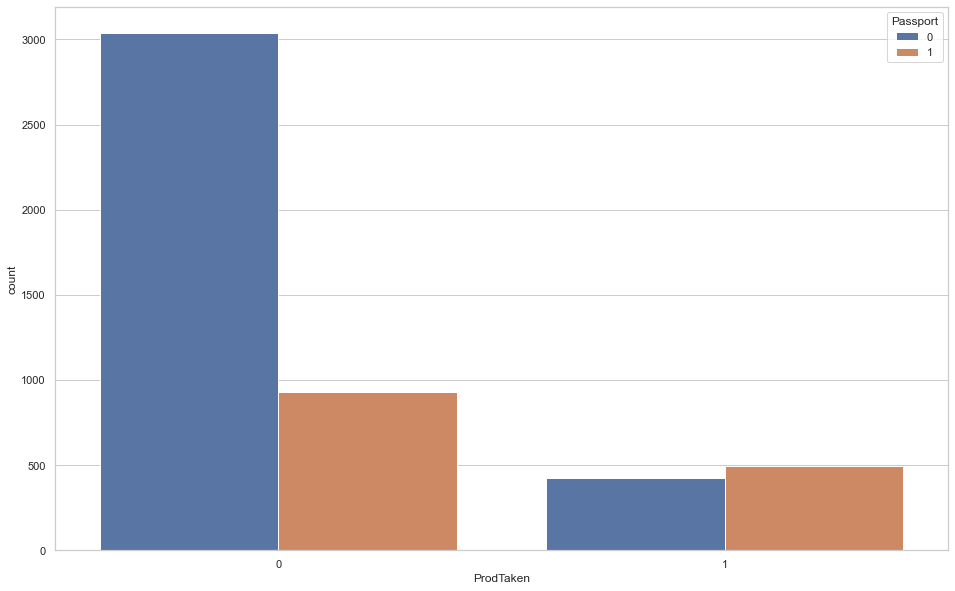

```python
sns.set_theme(style="whitegrid")
sns.countplot(data=df, x="ProdTaken", hue="Passport")
```

```python
df.groupby(["ProdTaken", "Passport"]).size()
```

```
ProdTaken  Passport
0          0           3040
           1            928
1          0            426
           1            494
dtype: int64
```

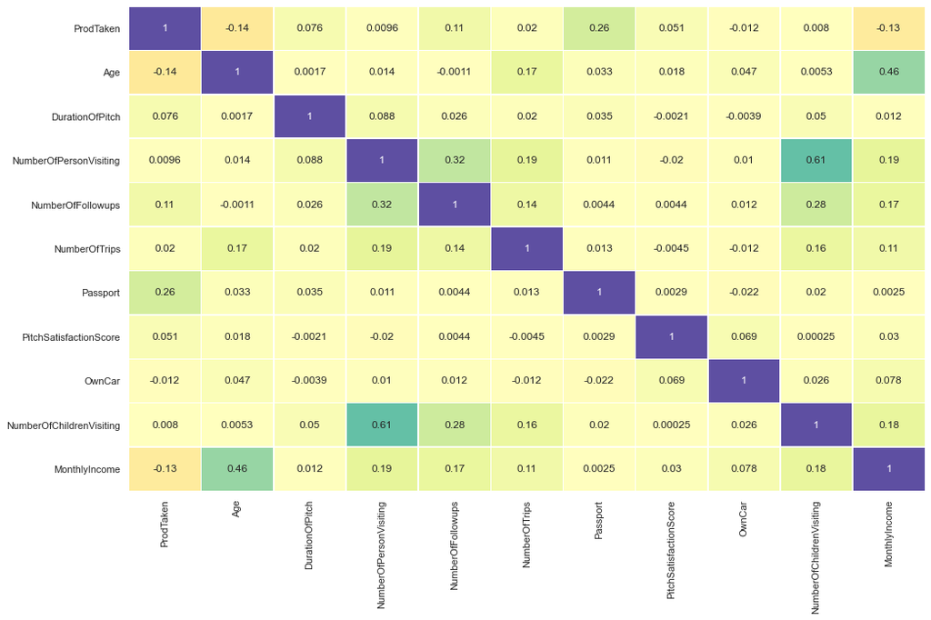

```python
sns.set(rc={"figure.figsize": (16, 10)})
sns.heatmap(
    df.corr(), annot=True, linewidths=0.5, center=0, cbar=False, cmap="Spectral"
)
plt.show()
```

- The only variable that is remotely highly correlated in the number of people visiting and the number of children visiting. Which we alread talked about above.
- There is also nothing that is super negatively correlated.

# Customer Profiling Insights

```python
# Creating a column for One Hot Encoding
oneHotCols = [
    "TypeofContact",
    "CityTier",
    "Occupation",
    "Gender",
    "ProductPitched",
    "PreferredPropertyStar",
    "MaritalStatus",
    "Designation",
]
```

```python
# I like to make a copy here incase I feel like something is not going correctly it is easier to make changes.
ready = df.copy()
```

```python
# Preparing the data
ready=pd.get_dummies(ready, columns=oneHotCols)
ready.head(10)
```

|  | ProdTaken | Age | DurationOfPitch | NumberOfPersonVisiting | NumberOfFollowups | NumberOfTrips | Passport | PitchSatisfactionScore | OwnCar | NumberOfChildrenVisiting | MonthlyIncome | TypeofContact_Company Invited | TypeofContact_Self Enquiry | CityTier_1 | CityTier_2 | CityTier_3 | Occupation_Large Business | Occupation_Salaried | Occupation_Small Business | Gender_Female | Gender_Male | ProductPitched_Basic | ProductPitched_Deluxe | ProductPitched_King | ProductPitched_Standard | ProductPitched_Super Deluxe | PreferredPropertyStar_3.0 | PreferredPropertyStar_4.0 | PreferredPropertyStar_5.0 | … |
| --- | --- | --- | --- | --- | --- | --- | --- | --- | --- | --- | --- | --- | --- | --- | --- | --- | --- | --- | --- | --- | --- | --- | --- | --- | --- | --- | --- | --- | --- | --- |
| 0 | 1 | 41.0 | 6.0 | 3 | 3.0 | 1.0 | 1 | 2 | 1 | 0.0 | 20993.0 | 0 | 1 | 0 | 0 | 1 | 0 | 1 | 0 | 1 | 0 | 0 | 1 | 0 | 0 | 0 | 1 | 0 | 0 | … |
| 1 | 0 | 49.0 | 14.0 | 3 | 4.0 | 2.0 | 0 | 3 | 1 | 2.0 | 20130.0 | 1 | 0 | 1 | 0 | 0 | 0 | 1 | 0 | 0 | 1 | 0 | 1 | 0 | 0 | 0 | 0 | 1 | 0 | … |
| 2 | 1 | 37.0 | 8.0 | 3 | 4.0 | 7.0 | 1 | 3 | 0 | 0.0 | 17090.0 | 0 | 1 | 1 | 0 | 0 | 0 | 0 | 1 | 0 | 1 | 1 | 0 | 0 | 0 | 0 | 1 | 0 | 0 | … |
| 3 | 0 | 33.0 | 9.0 | 2 | 3.0 | 2.0 | 1 | 5 | 1 | 1.0 | 17909.0 | 1 | 0 | 1 | 0 | 0 | 0 | 1 | 0 | 1 | 0 | 1 | 0 | 0 | 0 | 0 | 1 | 0 | 0 | … |
| 4 | 0 | 37.0 | 8.0 | 2 | 3.0 | 1.0 | 0 | 5 | 1 | 0.0 | 18468.0 | 0 | 1 | 1 | 0 | 0 | 0 | 0 | 1 | 0 | 1 | 1 | 0 | 0 | 0 | 0 | 0 | 1 | 0 | … |
| 5 | 0 | 32.0 | 8.0 | 3 | 3.0 | 1.0 | 0 | 5 | 1 | 1.0 | 18068.0 | 1 | 0 | 1 | 0 | 0 | 0 | 1 | 0 | 0 | 1 | 1 | 0 | 0 | 0 | 0 | 1 | 0 | 0 | … |
| 6 | 0 | 59.0 | 9.0 | 2 | 2.0 | 5.0 | 1 | 2 | 1 | 1.0 | 17670.0 | 0 | 1 | 1 | 0 | 0 | 0 | 0 | 1 | 1 | 0 | 1 | 0 | 0 | 0 | 0 | 0 | 0 | 1 | … |
| 7 | 0 | 30.0 | 30.0 | 3 | 3.0 | 2.0 | 0 | 2 | 0 | 1.0 | 17693.0 | 0 | 1 | 1 | 0 | 0 | 0 | 1 | 0 | 0 | 1 | 1 | 0 | 0 | 0 | 0 | 1 | 0 | 0 | … |
| 8 | 0 | 38.0 | 29.0 | 2 | 4.0 | 1.0 | 0 | 3 | 0 | 0.0 | 24526.0 | 1 | 0 | 1 | 0 | 0 | 0 | 1 | 0 | 0 | 1 | 0 | 0 | 0 | 1 | 0 | 1 | 0 | 0 | … |
| 9 | 0 | 36.0 | 33.0 | 3 | 3.0 | 7.0 | 0 | 3 | 1 | 0.0 | 20237.0 | 0 | 1 | 1 | 0 | 0 | 0 | 0 | 1 | 0 | 1 | 0 | 1 | 0 | 0 | 0 | 1 | 0 | 0 | … |

```python
ready.info()
```

```
<class 'pandas.core.frame.DataFrame'>
RangeIndex: 4888 entries, 0 to 4887
Data columns (total 38 columns):
 #   Column                         Non-Null Count  Dtype
---  ------                         --------------  -----
 0   ProdTaken                      4888 non-null   int64
 1   Age                            4888 non-null   float64
 2   DurationOfPitch                4888 non-null   float64
 3   NumberOfPersonVisiting         4888 non-null   int64
 4   NumberOfFollowups              4888 non-null   float64
 5   NumberOfTrips                  4888 non-null   float64
 6   Passport                       4888 non-null   int64
 7   PitchSatisfactionScore         4888 non-null   int64
 8   OwnCar                         4888 non-null   int64
 9   NumberOfChildrenVisiting       4888 non-null   float64
```

[output cut: 30 more lines]

- We can see here that there are no more categorical variables in the list.

## Split the data into train and test sets

- When data (classification) exhibit a significant imbalance in the distribution of the target classes, it is good to use stratified sampling to ensure that relative class frequencies are approximately preserved in train and test sets.
- This is done by setting the `stratify` parameter to target variable in the train_test_split function.

```python
X = ready.drop("ProdTaken", axis=1)
y = ready.pop("ProdTaken")
```

```python
X_train, X_test, y_train, y_test = train_test_split(
    X, y, test_size=0.30, random_state=1, stratify=y
)
```

**Before building the model, let's create functions to calculate different metrics- Accuracy, Recall and Precision and plot the confusion matrix.**

```python
## Function to create confusion matrix
def make_confusion_matrix(model, y_actual, labels=[1, 0]):
    """
    model : classifier to predict values of X
    y_actual : ground truth

    """
    y_predict = model.predict(X_test)
    cm = metrics.confusion_matrix(y_actual, y_predict, labels=[0, 1])
    df_cm = pd.DataFrame(
        cm,
        index=[i for i in ["Actual - No", "Actual - Yes"]],
        columns=[i for i in ["Predicted - No", "Predicted - Yes"]],
    )
    group_counts = ["{0:0.0f}".format(value) for value in cm.flatten()]
    group_percentages = ["{0:.2%}".format(value) for value in cm.flatten() / np.sum(cm)]
    labels = [f"{v1}\n{v2}" for v1, v2 in zip(group_counts, group_percentages)]
    labels = np.asarray(labels).reshape(2, 2)
    plt.figure(figsize=(10, 7))
    sns.heatmap(df_cm, annot=labels, fmt="")
    plt.ylabel("True label")
    plt.xlabel("Predicted label")
```

```python
##  Function to calculate different metric scores of the model - Accuracy, Recall and Precision
def get_metrics_score(model, flag=True):
    """
    model : classifier to predict values of X

    """
    # defining an empty list to store train and test results
    score_list = []

    pred_train = model.predict(X_train)
    pred_test = model.predict(X_test)

    train_acc = model.score(X_train, y_train)
    test_acc = model.score(X_test, y_test)

    train_recall = metrics.recall_score(y_train, pred_train)
    test_recall = metrics.recall_score(y_test, pred_test)

    train_precision = metrics.precision_score(y_train, pred_train)
    test_precision = metrics.precision_score(y_test, pred_test)

    train_F1 = 2 * ((train_precision * train_recall) / (train_precision + train_recall))
    test_F1 = 2 * ((test_precision * test_recall) / (test_precision + test_recall))

    score_list.extend(
        (
            train_acc,
            test_acc,
            train_recall,
            test_recall,
            train_precision,
            test_precision,
            train_F1,
            test_F1,
        )
    )

    # If the flag is set to True then only the following print statements will be dispayed. The default value is set to True.
    if flag == True:
        print("Accuracy on training set : ", model.score(X_train, y_train))
        print("Accuracy on test set : ", model.score(X_test, y_test))
        print("Recall on training set : ", metrics.recall_score(y_train, pred_train))
        print("Recall on test set : ", metrics.recall_score(y_test, pred_test))
        print(
            "Precision on training set : ", metrics.precision_score(y_train, pred_train)
        )
        print("Precision on test set : ", metrics.precision_score(y_test, pred_test))
        print("F1 score on training set : ", train_F1)
        print("F1 score on testing set : ", test_F1)

    return score_list  # returning the list with train and test scores
```

## Building the model

### Bagging Classifier

```python
# base_estimator for bagging classifier is a decision tree by default
bagging_estimator = BaggingClassifier(random_state=1)
bagging_estimator.fit(X_train, y_train)
```

```
BaggingClassifier(random_state=1)
```

```python
# Using above defined function to get accuracy, recall and precision on train and test set
bagging_estimator_score = get_metrics_score(bagging_estimator)
```

```
Accuracy on training set :  0.994153756211634
Accuracy on test set :  0.9100204498977505
Recall on training set :  0.9704968944099379
Recall on test set :  0.605072463768116
Precision on training set :  0.9984025559105432
Precision on test set :  0.8789473684210526
F1 score on training set :  0.984251968503937
F1 score on testing set :  0.7167381974248926
```

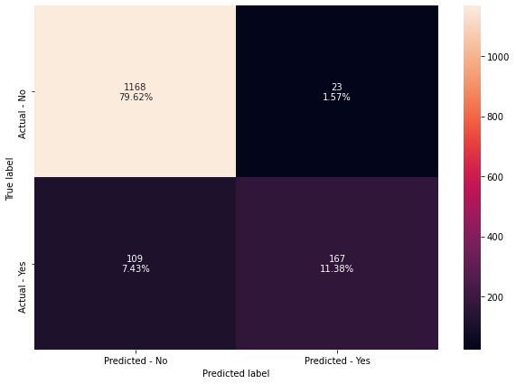

```python
make_confusion_matrix(bagging_estimator, y_test)
```

```python
print(df.ProdTaken.value_counts())
# 0 == No and 1 == Yes
```

```
0    3968
1     920
Name: ProdTaken, dtype: int64
```

### Insights

- We have calculated all three metrics here, Accuracy, Recall, and Precision.
- In this case were we are looking at identifying whether a person bought a package or not.
- What is really important is to identify all the people who did buy a package. We want to figure out why and enhance those reasons to attract more buyers.
- We know that decision trees tend to overfit so have an accuracy score of 99.4% is somewhat expected. What is not expected is to see how well the score for accuracy is on the testing data. The score of 91% shows us that model is could be a great model. But we need to look further and evaluate the the Recall and Precision scores.
- Recall is the number of true positives divided by the number of true positives plus the number of false negatives. Recall is the ability of a model to find all the relevant cases within a data set. $ recall = \frac{true positives}{true positives + false negatives} $
- In this case, optimal recall would be 100% in correctly predicting whether a person buys a package.
- Precision is the number of true positives divided by the number of true positives plus the number of false positives. Precision is the ability of a classification midel to identify only the relevant data points. $ precision = \frac{true positives}{true positives + false positives} $
- Predicting almost all cases as negative will let us reach a precision of 100%.
- When we increase the recall, we decrease the precision.
- To find a harmonic mean, or balance of precision and recall, we can find the $F_{1}$ score. We use the harmonic mean instead of a simple average because it punishes extreme values. $ F_{1} = 2 * \frac{precision * recall} {precision + recall} $
- Here we can see that the $F_{1}$ score for training and test are 98.4% and 71.6% respectively.

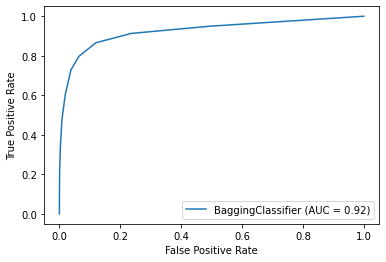

```python
metrics.plot_roc_curve(bagging_estimator, X_test, y_test)
plt.show()
```

- The AUC falls between zero and one wut a higher number indicating better classification performance.

### Random Forest Classifier

```python
# Train the random forest classifier
rf_estimator = RandomForestClassifier(random_state=1)
rf_estimator.fit(X_train, y_train)
```

```
RandomForestClassifier(random_state=1)
```

```python
# Using above defined function to get accuracy, recall and precision on train and test set
rf_estimator_score = get_metrics_score(rf_estimator)
```

```
Accuracy on training set :  1.0
Accuracy on test set :  0.9202453987730062
Recall on training set :  1.0
Recall on test set :  0.6195652173913043
Precision on training set :  1.0
Precision on test set :  0.9344262295081968
F1 score on training set :  1.0
F1 score on testing set :  0.7450980392156863
```

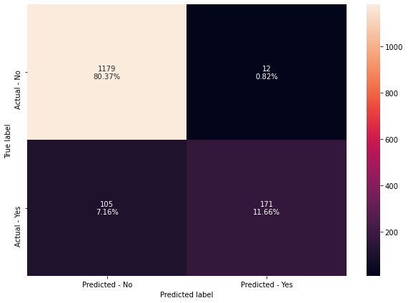

```python
make_confusion_matrix(rf_estimator, y_test)
```

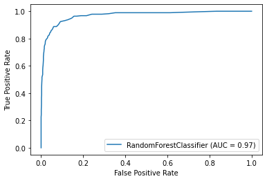

```python
metrics.plot_roc_curve(rf_estimator, X_test, y_test)
plt.show()
```

### Insights

- The scores on all the training data is clearly overfitted.
- The recall, precision, and $F_{1}$ score show similar results explained above under Bagging Classifier.
- The AUC shows that this random forest classification model is performing slightly better.

## Hyperparameter Tuning

### Bagging Classifier

**Some of the important hyperparameters available for bagging classifier are:**

- base_estimator: The base estimator to fit on random subsets of the dataset. If None(default), then the base estimator is a decision tree.
- n_estimators: The number of trees in the forest, default = 100.
- max_features: The number of features to consider when looking for the best split.
- bootstrap: Whether bootstrap samples are used when building trees. If False, the entire dataset is used to build each tree, default=True.
- bootstrap_features: If it is true, then features are drawn with replacement. Default value is False.
- max_samples: If bootstrap is True, then the number of samples to draw from X to train each base estimator. If None (default), then draw N samples, where N is the number of observations in the train data.
- oob_score: Whether to use out-of-bag samples to estimate the generalization accuracy, default=False.

```python
# Choose the type of classifier.
bagging_estimator_tuned = BaggingClassifier(random_state=1)

# Grid of parameters to choose from
## add from article
parameters = {
    "max_samples": [0.7, 0.8, 0.9, 1],
    "max_features": [0.7, 0.8, 0.9, 1],
    "n_estimators": [10, 20, 30, 40, 50],
}

# Type of scoring used to compare parameter combinations
acc_scorer = metrics.make_scorer(metrics.recall_score)

# Run the grid search
grid_obj = GridSearchCV(bagging_estimator_tuned, parameters, scoring=acc_scorer, cv=5)
grid_obj = grid_obj.fit(X_train, y_train)

# Set the clf to the best combination of parameters
bagging_estimator_tuned = grid_obj.best_estimator_

# Fit the best algorithm to the data.
bagging_estimator_tuned.fit(X_train, y_train)
```

```
BaggingClassifier(max_features=0.9, max_samples=0.9, n_estimators=50,
                  random_state=1)
```

**Let's check different metrics for bagging classifier with best hyperparameters and build a confusion matrix.**

```python
# Using above defined function to get accuracy, recall and precision on train and test set
bagging_estimator_tuned_score = get_metrics_score(bagging_estimator_tuned)
```

```
Accuracy on training set :  1.0
Accuracy on test set :  0.9195637355146558
Recall on training set :  1.0
Recall on test set :  0.6340579710144928
Precision on training set :  1.0
Precision on test set :  0.9114583333333334
F1 score on training set :  1.0
F1 score on testing set :  0.747863247863248
```

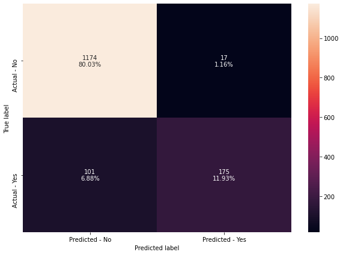

```python
make_confusion_matrix(bagging_estimator_tuned, y_test)
```

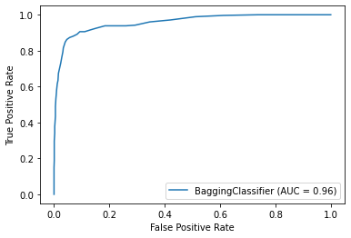

```python
metrics.plot_roc_curve(bagging_estimator_tuned, X_test, y_test)
plt.show()
```

### Insights

### Let's try using logistic regression as the base estimator for bagging classifier:

- Now, let's try and change the `base_estimator` of the bagging classifier, which is a decision tree by default.
- We will pass the logistic regression as the base estimator for bagging classifier.

```python
bagging_lr = BaggingClassifier(
    base_estimator=LogisticRegression(solver="liblinear", random_state=1),
    random_state=1,
)
bagging_lr.fit(X_train, y_train)
```

```
BaggingClassifier(base_estimator=LogisticRegression(random_state=1,
                                                    solver='liblinear'),
                  random_state=1)
```

```python
# Using above defined function to get accuracy, recall and precision on train and test set
bagging_lr_score = get_metrics_score(bagging_lr)
```

```
Accuracy on training set :  0.8146740719087986
Accuracy on test set :  0.8166325835037491
Recall on training set :  0.017080745341614908
Recall on test set :  0.028985507246376812
Precision on training set :  0.9166666666666666
Precision on test set :  0.8888888888888888
F1 score on training set :  0.03353658536585366
F1 score on testing set :  0.056140350877192984
```

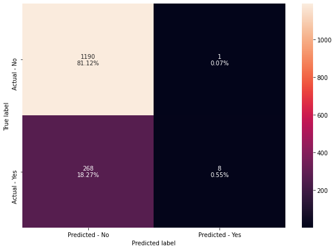

```python
make_confusion_matrix(bagging_lr, y_test)
```

```python
metrics.plot_roc_curve(bagging_lr, X_test, y_test)
plt.show()
```

[output not shown]

### Insights

### Random Forest Classifier

**Now, let's see if we can get a better model by tuning the random forest classifier. Some of the important hyperparameters available for random forest classifier are:**

- n_estimators: The number of trees in the forest, default = 100.
- max_features: The number of features to consider when looking for the best split.
- class_weight: Weights associated with classes in the form {class_label: weight}.If not given, all classes are supposed to have weight one.
- For example: If the frequency of class 0 is 80% and the frequency of class 1 is 20% in the data, then class 0 will become the dominant class and the model will become biased toward the dominant classes. In this case, we can pass a dictionary {0:0.2,1:0.8} to the model to specify the weight of each class and the random forest will give more weightage to class 1.
- bootstrap: Whether bootstrap samples are used when building trees. If False, the entire dataset is used to build each tree, default=True.
- max_samples: If bootstrap is True, then the number of samples to draw from X to train each base estimator. If None (default), then draw N samples, where N is the number of observations in the train data.
- oob_score: Whether to use out-of-bag samples to estimate the generalization accuracy, default=False.
- Note: A lot of hyperparameters of Decision Trees are also available to tune Random Forest like max_depth, min_sample_split etc.

```python
# Choose the type of classifier.
rf_estimator_tuned = RandomForestClassifier(random_state=1)

# Grid of parameters to choose from
## add from article
parameters = {
    "n_estimators": [30, 50, 100],
    "min_samples_leaf": np.arange(5, 10),
    "max_features": np.arange(0.2, 0.7, 0.1),
    "max_samples": np.arange(0.3, 0.7, 0.1),
}

# Type of scoring used to compare parameter combinations
acc_scorer = metrics.make_scorer(metrics.recall_score)

# Run the grid search
grid_obj = GridSearchCV(rf_estimator_tuned, parameters, scoring=acc_scorer, cv=5)
grid_obj = grid_obj.fit(X_train, y_train)

# Set the clf to the best combination of parameters
rf_estimator_tuned = grid_obj.best_estimator_

# Fit the best algorithm to the data.
rf_estimator_tuned.fit(X_train, y_train)
```

```
RandomForestClassifier(max_features=0.6000000000000001,
                       max_samples=0.6000000000000001, min_samples_leaf=5,
                       random_state=1)
```

```python
# Using above defined function to get accuracy, recall and precision on train and test set
rf_estimator_tuned_score = get_metrics_score(rf_estimator_tuned)
```

```
Accuracy on training set :  0.909967845659164
Accuracy on test set :  0.8766189502385822
Recall on training set :  0.5481366459627329
Recall on test set :  0.4166666666666667
Precision on training set :  0.9540540540540541
Precision on test set :  0.8518518518518519
F1 score on training set :  0.6962524654832348
F1 score on testing set :  0.559610705596107
```

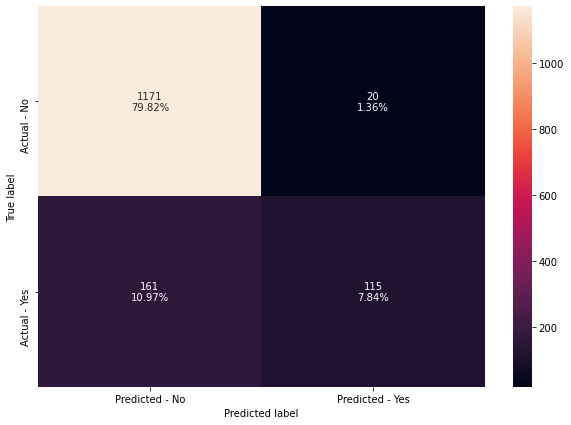

```python
make_confusion_matrix(rf_estimator_tuned, y_test)
```

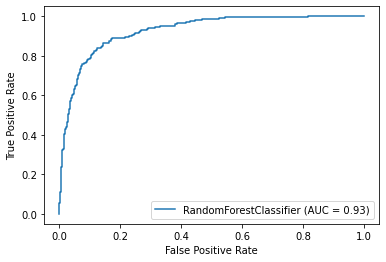

```python
metrics.plot_roc_curve(rf_estimator_tuned, X_test, y_test)
plt.show()
```

### Insights

### Let's try using class_weights for random forest:

```python
# Choose the type of classifier.
rf_estimator_weighted = RandomForestClassifier(random_state=1)

# Grid of parameters to choose from
## add from article
parameters = {
    "class_weight": [{0: 0.3, 1: 0.7}],
    "n_estimators": [30, 50, 100, 130],
    "min_samples_leaf": np.arange(5, 10),
    "max_features": np.arange(0.2, 0.7, 0.1),
    "max_samples": np.arange(0.3, 0.7, 0.1),
}

# Type of scoring used to compare parameter combinations
acc_scorer = metrics.make_scorer(metrics.recall_score)

# Run the grid search
grid_obj = GridSearchCV(rf_estimator_weighted, parameters, scoring=acc_scorer, cv=5)
grid_obj = grid_obj.fit(X_train, y_train)

# Set the clf to the best combination of parameters
rf_estimator_weighted = grid_obj.best_estimator_

# Fit the best algorithm to the data.
rf_estimator_weighted.fit(X_train, y_train)
```

```
RandomForestClassifier(class_weight={0: 0.3, 1: 0.7},
                       max_features=0.6000000000000001,
                       max_samples=0.6000000000000001, min_samples_leaf=6,
                       n_estimators=30, random_state=1)
```

```python
# Using above defined function to get accuracy, recall and precision on train and test set
rf_estimator_weighted_score = get_metrics_score(rf_estimator_weighted)
```

```
Accuracy on training set :  0.92955276235019
Accuracy on test set :  0.8738922972051807
Recall on training set :  0.7562111801242236
Recall on test set :  0.5144927536231884
Precision on training set :  0.8528896672504378
Precision on test set :  0.7357512953367875
F1 score on training set :  0.8016460905349795
F1 score on testing set :  0.6055437100213218
```

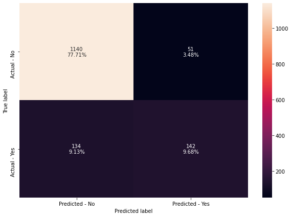

```python
make_confusion_matrix(rf_estimator_weighted, y_test)
```

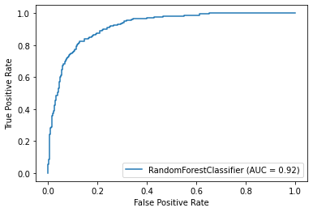

```python
metrics.plot_roc_curve(rf_estimator_weighted, X_test, y_test)
plt.show()
```

### Insights

### Checking the feature importance

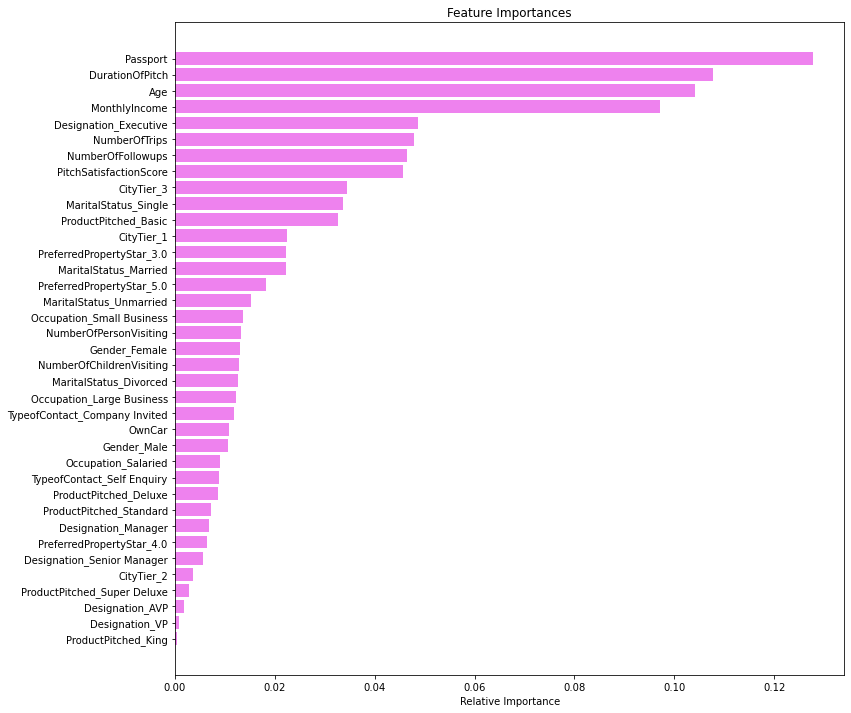

```python
importances = rf_estimator_weighted.feature_importances_
indices = np.argsort(importances)
feature_names = list(X.columns)

plt.figure(figsize=(12, 12))
plt.title("Feature Importances")
plt.barh(range(len(indices)), importances[indices], color="violet", align="center")
plt.yticks(range(len(indices)), [feature_names[i] for i in indices])
plt.xlabel("Relative Importance")
plt.show()
```

### Comparing all models till now

```python
# defining list of models
models = [
    bagging_estimator,
    bagging_estimator_tuned,
    bagging_lr,
    rf_estimator,
    rf_estimator_tuned,
    rf_estimator_weighted,
]

# defining empty lists to add train and test results
acc_train = []
acc_test = []
recall_train = []
recall_test = []
precision_train = []
precision_test = []
F1_train = []
F1_test = []

# looping through all the models to get the accuracy, precall and precision scores
for model in models:
    j = get_metrics_score(model, False)
    acc_train.append(np.round(j[0], 2))
    acc_test.append(np.round(j[1], 2))
    recall_train.append(np.round(j[2], 2))
    recall_test.append(np.round(j[3], 2))
    precision_train.append(np.round(j[4], 2))
    precision_test.append(np.round(j[5], 2))
    F1_train.append(np.round(j[4], 2))
    F1_test.append(np.round(j[5], 2))
```

```python
comparison_frame = pd.DataFrame(
    {
        "Model": [
            "Bagging classifier with default parameters",
            "Tuned Bagging Classifier",
            "Bagging classifier with base_estimator=LR",
            "Random Forest with deafult parameters",
            "Tuned Random Forest Classifier",
            "Random Forest with class_weights",
        ],
        "Train_Accuracy": acc_train,
        "Test_Accuracy": acc_test,
        "Train_Recall": recall_train,
        "Test_Recall": recall_test,
        "Train_Precision": precision_train,
        "Test_Precision": precision_test,
        "Train_F1_Score": F1_train,
        "Test_F1_Score": F1_test,
    }
)
comparison_frame
```

[output not shown]

### Note:

# Ensemble Hands On - Boosting

**We will use the same functions, created in bagging hands-on lecture, to calculate different metrics and plot the confusion matrix.**

## Building the model

### AdaBoost Classifier

```python
abc = AdaBoostClassifier(random_state=1)
abc.fit(X_train, y_train)
```

```
AdaBoostClassifier(random_state=1)
```

```python
# Using above defined function to get accuracy, recall and precision on train and test set
abc_score = get_metrics_score(abc)
```

```
Accuracy on training set :  0.844489915229465
Accuracy on test set :  0.8500340831629175
Recall on training set :  0.31832298136645965
Recall on test set :  0.32608695652173914
Precision on training set :  0.6879194630872483
Precision on test set :  0.7258064516129032
F1 score on training set :  0.43524416135881105
F1 score on testing set :  0.45000000000000007
```

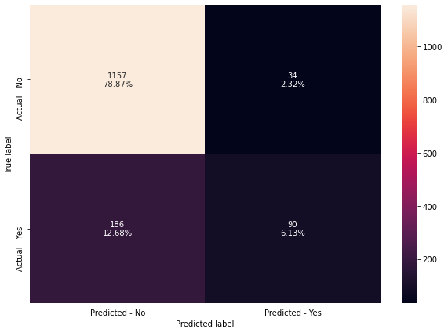

```python
make_confusion_matrix(abc, y_test)
```

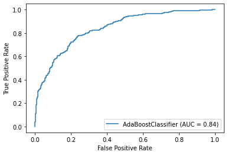

```python
metrics.plot_roc_curve(abc, X_test, y_test)
plt.show()
```

### Gradient Boosting Classifier

```python
gbc = GradientBoostingClassifier(random_state=1)
gbc.fit(X_train, y_train)
```

```
GradientBoostingClassifier(random_state=1)
```

```python
# Using above defined function to get accuracy, recall and precision on train and test set
gbc_score = get_metrics_score(gbc)
```

```
Accuracy on training set :  0.8886290558316282
Accuracy on test set :  0.869120654396728
Recall on training set :  0.4642857142857143
Recall on test set :  0.40942028985507245
Precision on training set :  0.8925373134328358
Precision on test set :  0.795774647887324
F1 score on training set :  0.6108273748723188
F1 score on testing set :  0.5406698564593302
```

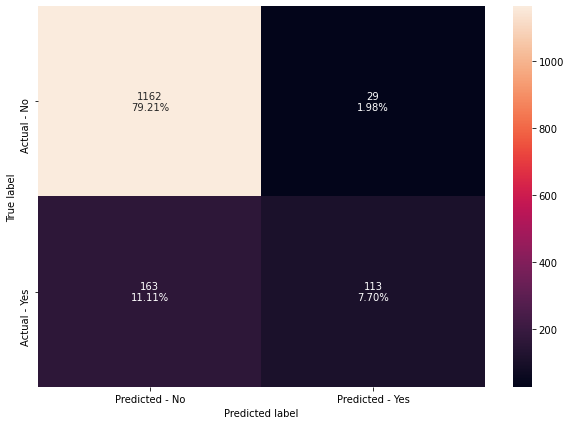

```python
make_confusion_matrix(gbc, y_test)
```

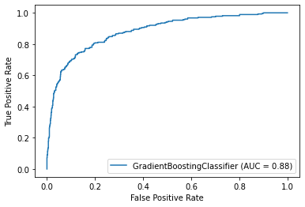

```python
metrics.plot_roc_curve(gbc, X_test, y_test)
plt.show()
```

### XGBoost Classifier

```python
xgb = XGBClassifier(random_state=1, eval_metric="logloss")
xgb.fit(X_train, y_train)
```

```
XGBClassifier(eval_metric='logloss', random_state=1)
```

```python
# Using above defined function to get accuracy, recall and precision on train and test set
xgb_score = get_metrics_score(xgb)
```

```
Accuracy on training set :  0.8810289389067524
Accuracy on test set :  0.8623040218132243
Recall on training set :  0.43167701863354035
Recall on test set :  0.36231884057971014
Precision on training set :  0.8714733542319749
Precision on test set :  0.7936507936507936
F1 score on training set :  0.57736240913811
F1 score on testing set :  0.49751243781094534
```

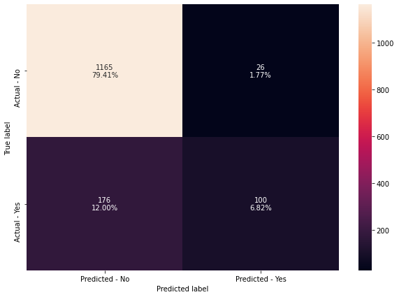

```python
make_confusion_matrix(xgb, y_test)
```

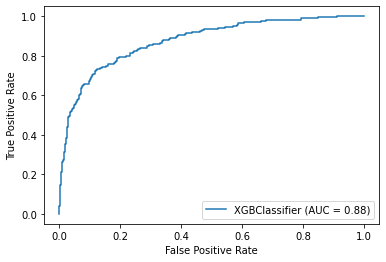

```python
metrics.plot_roc_curve(xgb, X_test, y_test)
plt.show()
```

## Hyperparameter Tuning

### AdaBoost Classifier

- An AdaBoost classifier is a meta-estimator that begins by fitting a classifier on the original dataset and then fits additional copies of the classifier on the same dataset but where the weights of incorrectly classified instances are adjusted such that subsequent classifiers focus more on difficult cases.
- Some important hyperparamters are:
  - base_estimator: The base estimator from which the boosted ensemble is built. By default the base estimator is a decision tree with max_depth=1
  - n_estimators: The maximum number of estimators at which boosting is terminated. Default value is 50.
  - learning_rate: Learning rate shrinks the contribution of each classifier by learning_rate. There is a trade-off between learning_rate and n_estimators.

```python
# Choose the type of classifier.
abc_tuned = AdaBoostClassifier(random_state=1)

# Grid of parameters to choose from
## add from article
parameters = {
    # Let's try different max_depth for base_estimator
    "base_estimator": [
        DecisionTreeClassifier(max_depth=1, random_state=1),
        DecisionTreeClassifier(max_depth=2, random_state=1),
        DecisionTreeClassifier(max_depth=3, random_state=1),
    ],
    "n_estimators": np.arange(10, 110, 10),
    "learning_rate": np.arange(0.1, 2, 0.1),
}

# Type of scoring used to compare parameter combinations
acc_scorer = metrics.make_scorer(metrics.recall_score)

# Run the grid search
grid_obj = GridSearchCV(abc_tuned, parameters, scoring=acc_scorer, cv=5)
grid_obj = grid_obj.fit(X_train, y_train)

# Set the clf to the best combination of parameters
abc_tuned = grid_obj.best_estimator_

# Fit the best algorithm to the data.
abc_tuned.fit(X_train, y_train)
```

```
AdaBoostClassifier(base_estimator=DecisionTreeClassifier(max_depth=3,
                                                         random_state=1),
                   learning_rate=1.8000000000000003, n_estimators=100,
                   random_state=1)
```

```python
# Using above defined function to get accuracy, recall and precision on train and test set
abc_tuned_score = get_metrics_score(abc_tuned)
```

```
Accuracy on training set :  0.9652148494592224
Accuracy on test set :  0.8554873892297206
Recall on training set :  0.8881987577639752
Recall on test set :  0.6086956521739131
Precision on training set :  0.9240710823909531
Precision on test set :  0.6176470588235294
F1 score on training set :  0.9057798891528107
F1 score on testing set :  0.6131386861313869
```

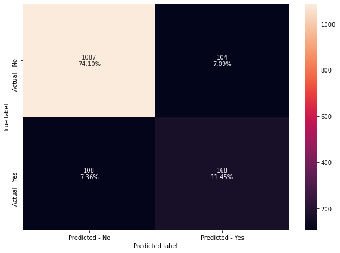

```python
make_confusion_matrix(abc_tuned, y_test)
```

[figure not shown]

```python
metrics.plot_roc_curve(abc, X_test, y_test)
plt.show()
```

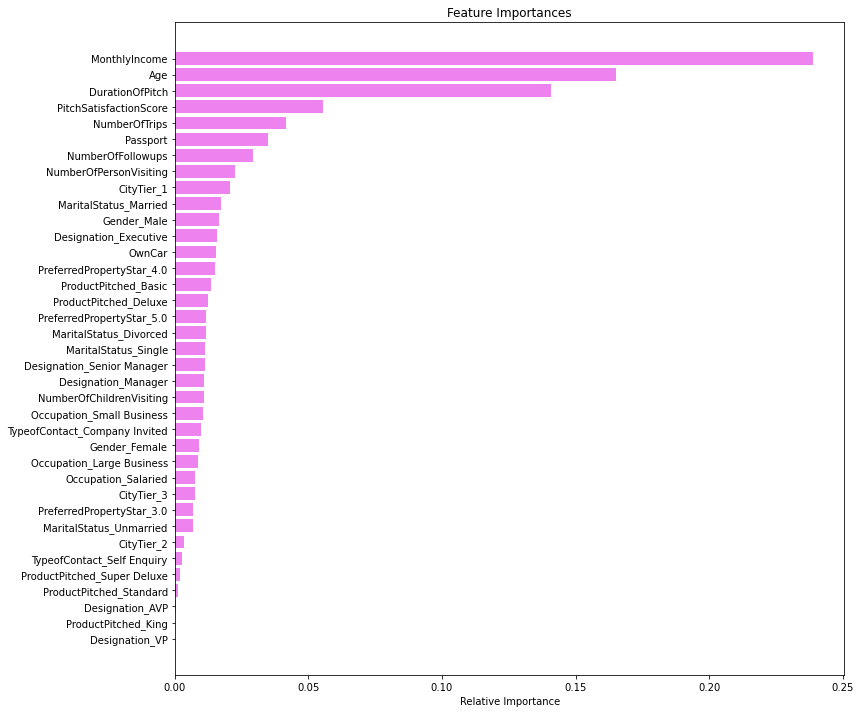

```python
importances = abc_tuned.feature_importances_
indices = np.argsort(importances)
feature_names = list(X.columns)

plt.figure(figsize=(12, 12))
plt.title("Feature Importances")
plt.barh(range(len(indices)), importances[indices], color="violet", align="center")
plt.yticks(range(len(indices)), [feature_names[i] for i in indices])
plt.xlabel("Relative Importance")
plt.show()
```

- Here we can see that the most important feature is Monthly Income.

### Gradient Boosting Classifier

- Most of the hyperparameters available are same as random forest classifier.
- init: An estimator object that is used to compute the initial predictions. If ‘zero’, the initial raw predictions are set to zero. By default, a DummyEstimator predicting the classes priors is used.
- There is no class_weights parameter in gradient boosting.

**Let's try using AdaBoost classifier as the estimator for initial predictions**

```python
gbc_init = GradientBoostingClassifier(
    init=AdaBoostClassifier(random_state=1), random_state=1
)
gbc_init.fit(X_train, y_train)
```

```
GradientBoostingClassifier(init=AdaBoostClassifier(random_state=1),
                           random_state=1)
```

```python
# Using above defined function to get accuracy, recall and precision on train and test set
gbc_init_score = get_metrics_score(gbc_init)
```

```
Accuracy on training set :  0.887459807073955
Accuracy on test set :  0.8670756646216768
Recall on training set :  0.45962732919254656
Recall on test set :  0.3804347826086957
Precision on training set :  0.8888888888888888
Precision on test set :  0.813953488372093
F1 score on training set :  0.6059365404298873
F1 score on testing set :  0.5185185185185186
```

**As compared to the model with default parameters:**

```python
# Choose the type of classifier.
gbc_tuned = GradientBoostingClassifier(
    init=AdaBoostClassifier(random_state=1), random_state=1
)

# Grid of parameters to choose from
## add from article
parameters = {
    "n_estimators": [100, 150, 200, 250],
    "subsample": [0.8, 0.9, 1],
    "max_features": [0.7, 0.8, 0.9, 1],
}

# Type of scoring used to compare parameter combinations
acc_scorer = metrics.make_scorer(metrics.recall_score)

# Run the grid search
grid_obj = GridSearchCV(gbc_tuned, parameters, scoring=acc_scorer, cv=5)
grid_obj = grid_obj.fit(X_train, y_train)

# Set the clf to the best combination of parameters
gbc_tuned = grid_obj.best_estimator_

# Fit the best algorithm to the data.
gbc_tuned.fit(X_train, y_train)
```

```
GradientBoostingClassifier(init=AdaBoostClassifier(random_state=1),
                           max_features=0.7, n_estimators=250, random_state=1,
                           subsample=0.9)
```

```python
# Using above defined function to get accuracy, recall and precision on train and test set
gbc_tuned_score = get_metrics_score(gbc_tuned)
```

```
Accuracy on training set :  0.9207833966676411
Accuracy on test set :  0.880027266530334
Recall on training set :  0.6226708074534162
Recall on test set :  0.4963768115942029
Precision on training set :  0.9347319347319347
Precision on test set :  0.7873563218390804
F1 score on training set :  0.7474370922646786
F1 score on testing set :  0.6088888888888888
```

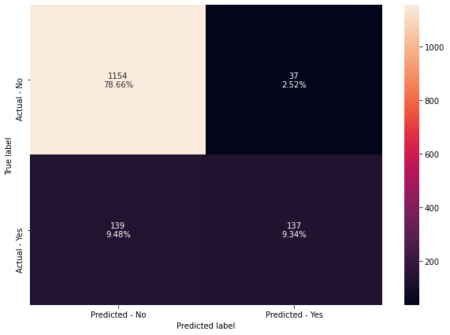

```python
make_confusion_matrix(gbc_tuned, y_test)
```

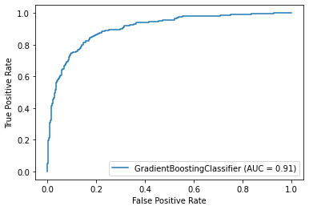

```python
metrics.plot_roc_curve(gbc_tuned, X_test, y_test)
plt.show()
```

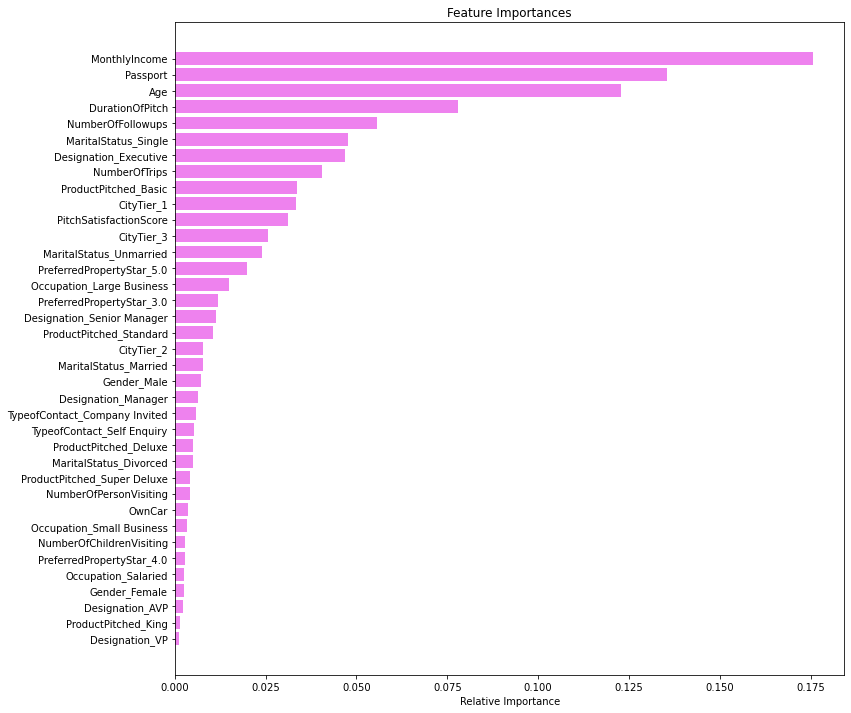

```python
importances = gbc_tuned.feature_importances_
indices = np.argsort(importances)
feature_names = list(X.columns)

plt.figure(figsize=(12, 12))
plt.title("Feature Importances")
plt.barh(range(len(indices)), importances[indices], color="violet", align="center")
plt.yticks(range(len(indices)), [feature_names[i] for i in indices])
plt.xlabel("Relative Importance")
plt.show()
```

### XGBoost Classifier

**XGBoost has many hyper parameters which can be tuned to increase the model performance. You can read about them in the xgboost documentation [here](https://xgboost.readthedocs.io/en/latest/parameter.html#general-parameters). Some of the important parameters are:**

- scale_pos_weight:Control the balance of positive and negative weights, useful for unbalanced classes. It has range from 0 to $\infty$.
- subsample: Corresponds to the fraction of observations (the rows) to subsample at each step. By default it is set to 1 meaning that we use all rows.
- colsample_bytree: Corresponds to the fraction of features (the columns) to use.
- colsample_bylevel: The subsample ratio of columns for each level. Columns are subsampled from the set of columns chosen for the current tree.
- colsample_bynode: The subsample ratio of columns for each node (split). Columns are subsampled from the set of columns chosen for the current level.
- max_depth: is the maximum number of nodes allowed from the root to the farthest leaf of a tree.
- learning_rate/eta: Makes the model more robust by shrinking the weights on each step.
- gamma: A node is split only when the resulting split gives a positive reduction in the loss function. Gamma specifies the minimum loss reduction required to make a split.

```python
# Choose the type of classifier.
xgb_tuned = XGBClassifier(random_state=1, eval_metric="logloss")

# Grid of parameters to choose from
## add from
parameters = {
    "n_estimators": np.arange(10, 100, 20),
    "scale_pos_weight": [0, 1, 2, 5],
    "subsample": [0.5, 0.7, 0.9, 1],
    "learning_rate": [0.01, 0.1, 0.2, 0.05],
    "gamma": [0, 1, 3],
    "colsample_bytree": [0.5, 0.7, 0.9, 1],
    "colsample_bylevel": [0.5, 0.7, 0.9, 1],
}

# Type of scoring used to compare parameter combinations
acc_scorer = metrics.make_scorer(metrics.recall_score)

# Run the grid search
grid_obj = GridSearchCV(xgb_tuned, parameters, scoring=acc_scorer, cv=5)
grid_obj = grid_obj.fit(X_train, y_train)

# Set the clf to the best combination of parameters
xgb_tuned = grid_obj.best_estimator_

# Fit the best algorithm to the data.
xgb_tuned.fit(X_train, y_train)
```

```
XGBClassifier(colsample_bylevel=0.5, colsample_bytree=0.5,
              eval_metric='logloss', gamma=3, learning_rate=0.01,
              n_estimators=30, random_state=1, scale_pos_weight=5,
              subsample=0.5)
```

```python
# Using above defined function to get accuracy, recall and precision on train and test set
xgb_tuned_score = get_metrics_score(xgb_tuned)
```

```
Accuracy on training set :  0.6664717918737212
Accuracy on test set :  0.6693933197000682
Recall on training set :  0.7670807453416149
Recall on test set :  0.782608695652174
Precision on training set :  0.33265993265993266
Precision on test set :  0.3369734789391576
F1 score on training set :  0.4640676373884453
F1 score on testing set :  0.4711014176663032
```

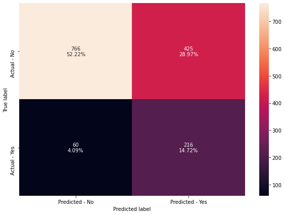

```python
make_confusion_matrix(xgb_tuned, y_test)
```

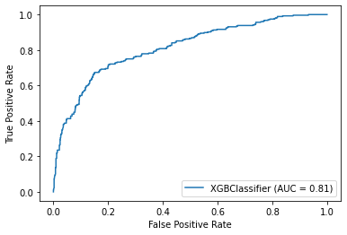

```python
metrics.plot_roc_curve(xgb_tuned, X_test, y_test)
plt.show()
```

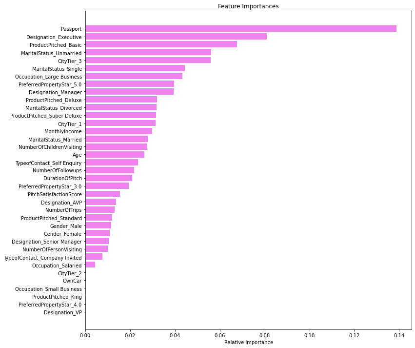

```python
importances = xgb_tuned.feature_importances_
indices = np.argsort(importances)
feature_names = list(X.columns)

plt.figure(figsize=(12, 12))
plt.title("Feature Importances")
plt.barh(range(len(indices)), importances[indices], color="violet", align="center")
plt.yticks(range(len(indices)), [feature_names[i] for i in indices])
plt.xlabel("Relative Importance")
plt.show()
```

## Stacking Classifier

```python
# defining a function to compute different metrics to check performance of a classification model built using sklearn
def model_performance_classification_sklearn(model, predictors, target):
    """
    Function to compute different metrics to check classification model performance

    model: classifier
    predictors: independent variables
    target: dependent variable
    """

    # predicting using the independent variables
    pred = model.predict(predictors)

    acc = accuracy_score(target, pred)  # to compute Accuracy
    recall = recall_score(target, pred)  # to compute Recall
    precision = precision_score(target, pred)  # to compute Precision
    f1 = f1_score(target, pred)  # to compute F1-score

    # creating a dataframe of metrics
    df_perf = pd.DataFrame(
        {
            "Accuracy": acc,
            "Recall": recall,
            "Precision": precision,
            "F1": f1,
        },
        index=[0],
    )

    return df_perf
```

```python
def confusion_matrix_sklearn(model, predictors, target):
    """
    To plot the confusion_matrix with percentages

    model: classifier
    predictors: independent variables
    target: dependent variable
    """
    y_pred = model.predict(predictors)
    cm = confusion_matrix(target, y_pred)
    labels = np.asarray(
        [
            ["{0:0.0f}".format(item) + "\n{0:.2%}".format(item / cm.flatten().sum())]
            for item in cm.flatten()
        ]
    ).reshape(2, 2)

    plt.figure(figsize=(6, 4))
    sns.heatmap(cm, annot=labels, fmt="")
    plt.ylabel("True label")
    plt.xlabel("Predicted label")
```

```python
from sklearn.ensemble import StackingClassifier

estimators = [
    ("Bagging", bagging_estimator),
    ("Bagging Estimator Tuned", bagging_estimator_tuned),
    ("Random Forest", rf_estimator_weighted),
    ("Gradient Boosting", gbc_tuned),
]

final_estimator = xgb_tuned

stacking_classifier = StackingClassifier(
    estimators=estimators, final_estimator=final_estimator
)

stacking_classifier.fit(X_train, y_train)
```

```
StackingClassifier(estimators=[('Bagging', BaggingClassifier(random_state=1)),
                               ('Bagging Estimator Tuned',
                                BaggingClassifier(max_features=0.9,
                                                  max_samples=0.9,
                                                  n_estimators=50,
                                                  random_state=1)),
                               ('Random Forest',
                                RandomForestClassifier(class_weight={0: 0.3,
                                                                     1: 0.7},
                                                       max_features=0.6000000000000001,
                                                       max_samples=0.6000000000000001,
                                                       min_samples_leaf=6,
                                                       n_estimators=30,
                                                       random_state=1)),
                               ('Gradient Boosting',
                                GradientBoostingClassifier(init=AdaBoostClassifier(random_state=1),
                                                           max_features=0.7,
                                                           n_estimators=250,
                                                           random_state=1,
                                                           subsample=0.9))],
                   final_estimator=XGBClassifier(colsample_bylevel=0.5,
                                                 colsample_bytree=0.5,
                                                 eval_metric='logloss', gamma=3,
                                                 learning_rate=0.01,
                                                 n_estimators=30,
                                                 random_state=1,
                                                 scale_pos_weight=5,
                                                 subsample=0.5))
```

```
Training performance:
    Accuracy  Recall  Precision        F1
0  0.984507     1.0    0.92396  0.960477
Testing performance:
    Accuracy   Recall  Precision        F1
0  0.895706  0.92029    0.65974  0.768533
```

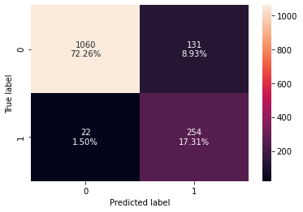

```python
from sklearn.metrics import (
    confusion_matrix,
    classification_report,
    accuracy_score,
    precision_score,
    recall_score,
    f1_score,
    roc_auc_score,
)

# Calculating different metrics
stacking_classifier_model_train_perf = model_performance_classification_sklearn(
    stacking_classifier, X_train, y_train
)
print("Training performance:\n", stacking_classifier_model_train_perf)
stacking_classifier_model_test_perf = model_performance_classification_sklearn(
    stacking_classifier, X_test, y_test
)
print("Testing performance:\n", stacking_classifier_model_test_perf)

# Creating confusion matrix
confusion_matrix_sklearn(stacking_classifier, X_test, y_test)
```

```python
metrics.plot_roc_curve(stacking_classifier, X_test, y_test)
plt.show()
```

[output not shown]

## Comparing all boosting models

```python
# defining list of models
models = [abc, abc_tuned, gbc, gbc_init, gbc_tuned, xgb, xgb_tuned]

# defining empty lists to add train and test results
acc_train = []
acc_test = []
recall_train = []
recall_test = []
precision_train = []
precision_test = []
F1_train = []
F1_test = []

# looping through all the models to get the accuracy, precall and precision scores
for model in models:
    j = get_metrics_score(model, False)
    acc_train.append(np.round(j[0], 2))
    acc_test.append(np.round(j[1], 2))
    recall_train.append(np.round(j[2], 2))
    recall_test.append(np.round(j[3], 2))
    precision_train.append(np.round(j[4], 2))
    precision_test.append(np.round(j[5], 2))
    F1_train.append(np.round(j[4], 2))
    F1_test.append(np.round(j[5], 2))
```

```python
comparison_frame = pd.DataFrame(
    {
        "Model": [
            "AdaBoost with default paramters",
            "AdaBoost Tuned",
            "Gradient Boosting with default parameters",
            "Gradient Boosting with init=AdaBoost",
            "Gradient Boosting Tuned",
            "XGBoost with default parameters",
            "XGBoost Tuned",
        ],
        "Train_Accuracy": acc_train,
        "Test_Accuracy": acc_test,
        "Train_Recall": recall_train,
        "Test_Recall": recall_test,
        "Train_Precision": precision_train,
        "Test_Precision": precision_test,
        "Train_F1_Score": F1_train,
        "Test_F1_Score": F1_test,
    }
)
comparison_frame
```

[output not shown]

# Insights

- After looking at the boosting models none of them performed that great and you can see that with the XGBoost Tuned. This is an area that if I wasn't running out of time, I would go back and adjust the estimators. I would also allow for more time to let the algorithms run.

# Business Insights Recommendations

# Recommendations